# NHC Patient Needs Survey: 2024 Results

Haleigh Schwartz

2025-01-29

# *Background:*

#### For several months, NHC staff and volunteers asked patients to fill out a survey to better inform the clinic of their needs. NHC gathered a holistic look at patients and asked about a variety of topics, from healthcare needs to food insecurity to transportation capabilities.

#### The survey gathered 157 responses, which resulted in a 90% confidence interval and 5% margin of error. This means that for any given result, the reader can be 90% confident the truth lies within +5% and -5% of the given result.

# *Results:*

### What are patient demographics of NHC?

#### NHC sees twice as many females than males. The split between languages is about even (48% English / 52% Spanish). Of the males that are seen at NHC, more are English-speaking (but the difference is almost even). The median age across languages and genders is 50 years old.

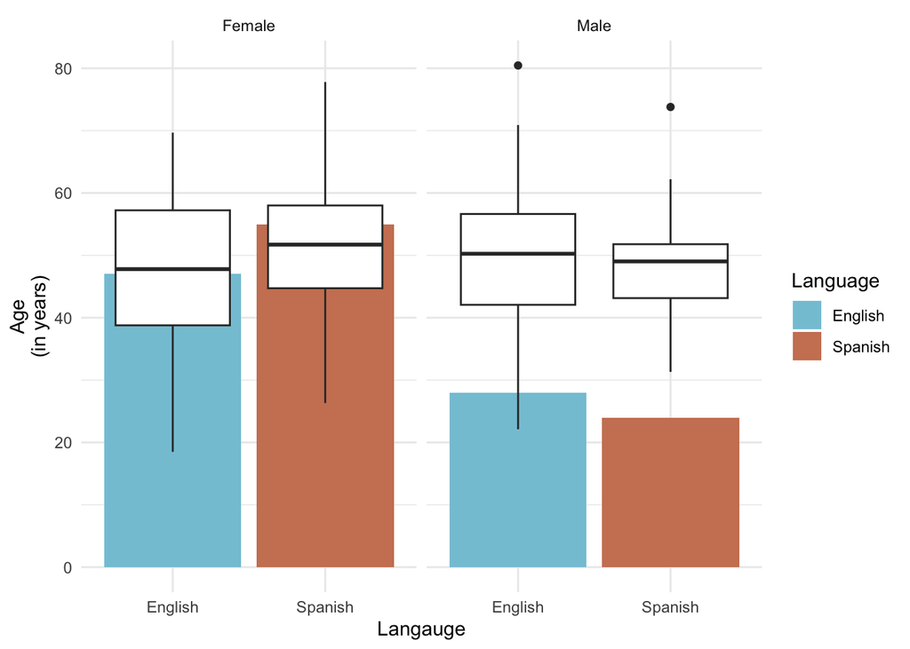

### What are financial situations of NHC patients?

#### **Federal Poverty Level:** After gathering up-to-date information, we confirmed the median federal poverty level of our patients is 100%.

##### (Previous analyses on this question was completed with out-of-date information.)

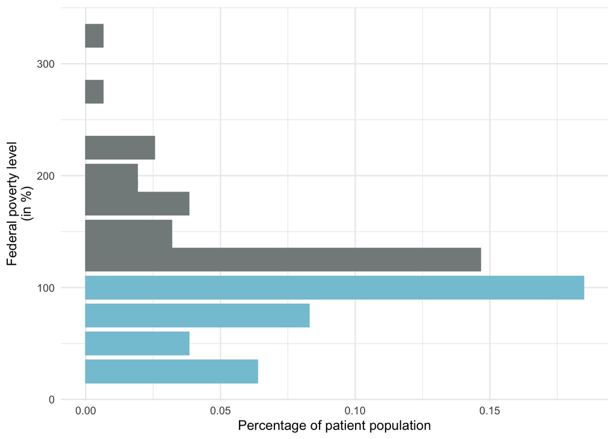

#### **Insurance Status:** 89% of NHC patients are uninsured. Of those who have insurance, most are on Medicaid or Medicare. Very few (1.3%) are on employer-provided insurance.

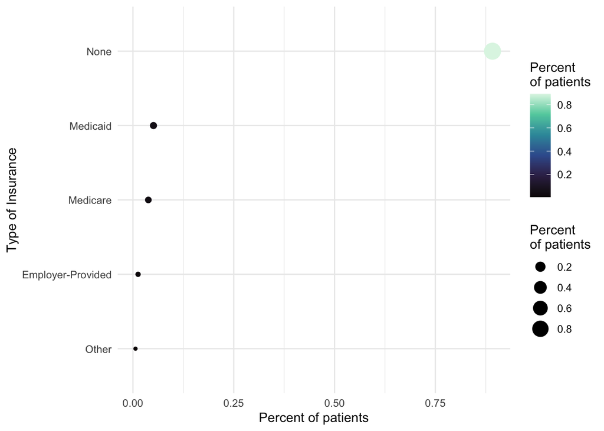

#### **Employment Status:** Less than half of NHC patients are working (48%), 24% are unemployed *and* looking for work, and 18% are unemployed but *not* looking for work.

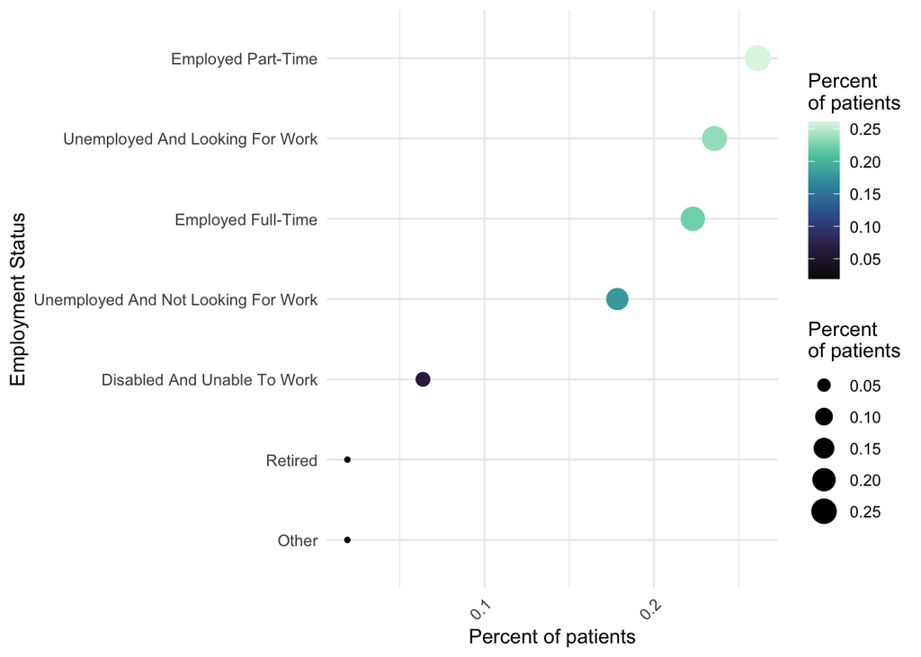

#### **Employment Status:** Most women seen at NHC are unemployed, while most men are employed.

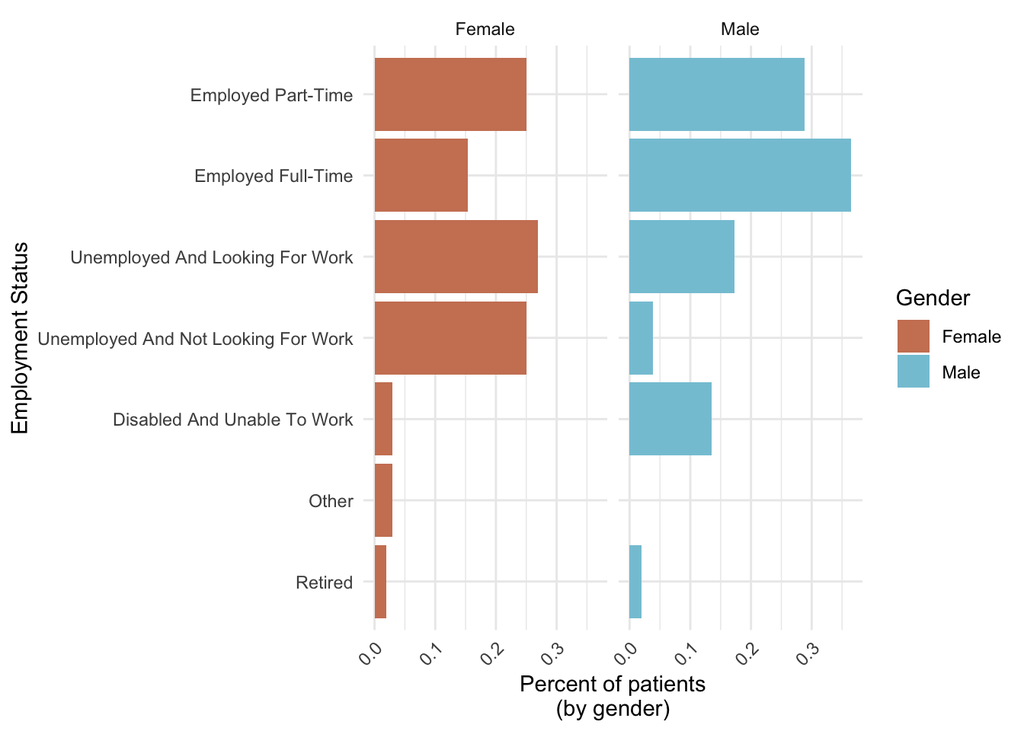

#### **Financial Assistance Programs:** Most patients (81%) are *not* using financial assistance programs (data not shown). Of those who are, 73% are using SNAP. This suggests there is some need for food assistance in the NHC patient population *and* an accessible way to receive it. See the next section for more details on the challenges and resources our patients have.

### What are the holistic needs of NHC patients?

#### **Healthcare:** 36% of NHC patients reported they did not have access to healthcare in the past 12 months. When asked why they could not access healthcare, the two most popular responses were *cost of care* and *not having insurance* (data not shown).

#### **Housing:** 59% of NHC patients are living in rented houses or apartments. 70% of patients have *not* experienced housing insecurity in the past 12 months. This distribution was equal across demographics such as gender, ethnicity, household size, and marital status.

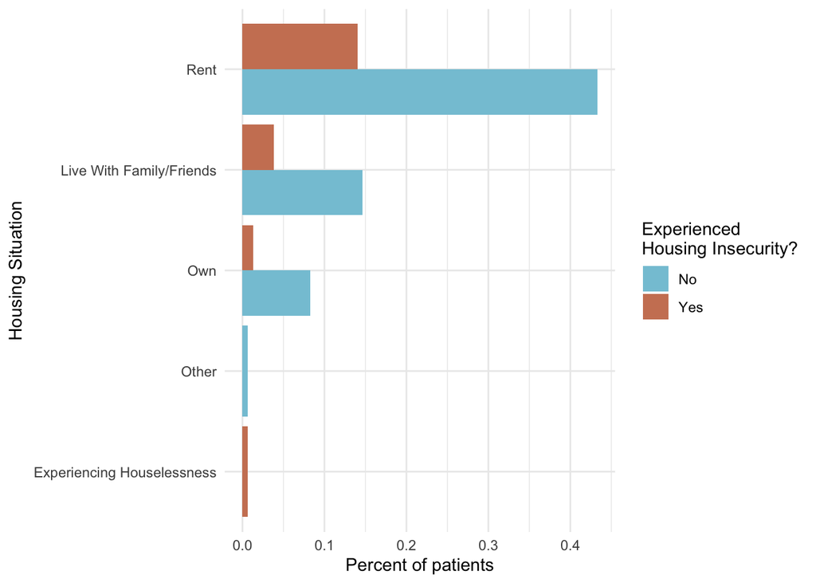

#### **Food:** 37% of NHC patients worry about having enough food either “sometimes” or “often.” These patients are consistently worrying about food, and always more often than those not on food assistance programs.

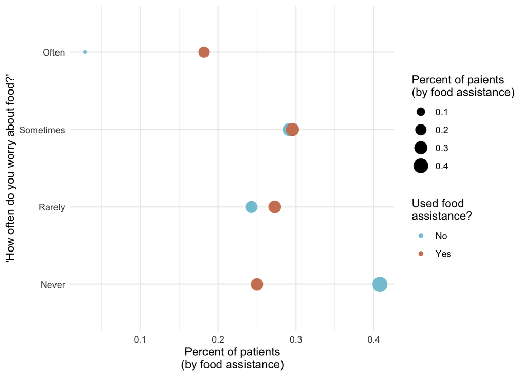

#### **Mental Health:** 24% of NHC patients experience poor mental health half or more days in a month. There were varied distributions in both gender, ethnicity, and employment status.

#### By gender, men were more likely to have either extreme response and women were more equally spread across the spectrum (data not shown).

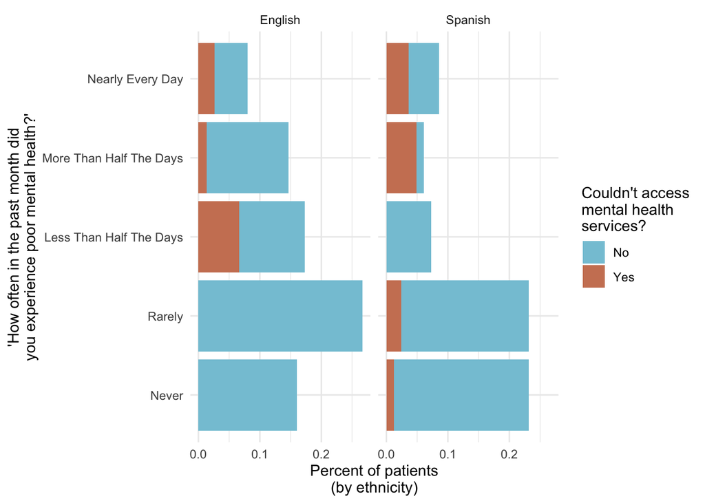

#### By employment status, the group that experiences the most poor mental health days in a month are those who are unemployed but looking for work. Those who are only working part time or who are not working are more likely to feel they cannot access mental health resources when they need it (data not shown).

#### **Challenge:** Besides finding healthcare resources, the greatest challenge NHC patients face is paying for utilities.

##### (39% of patients did not answer this question.)

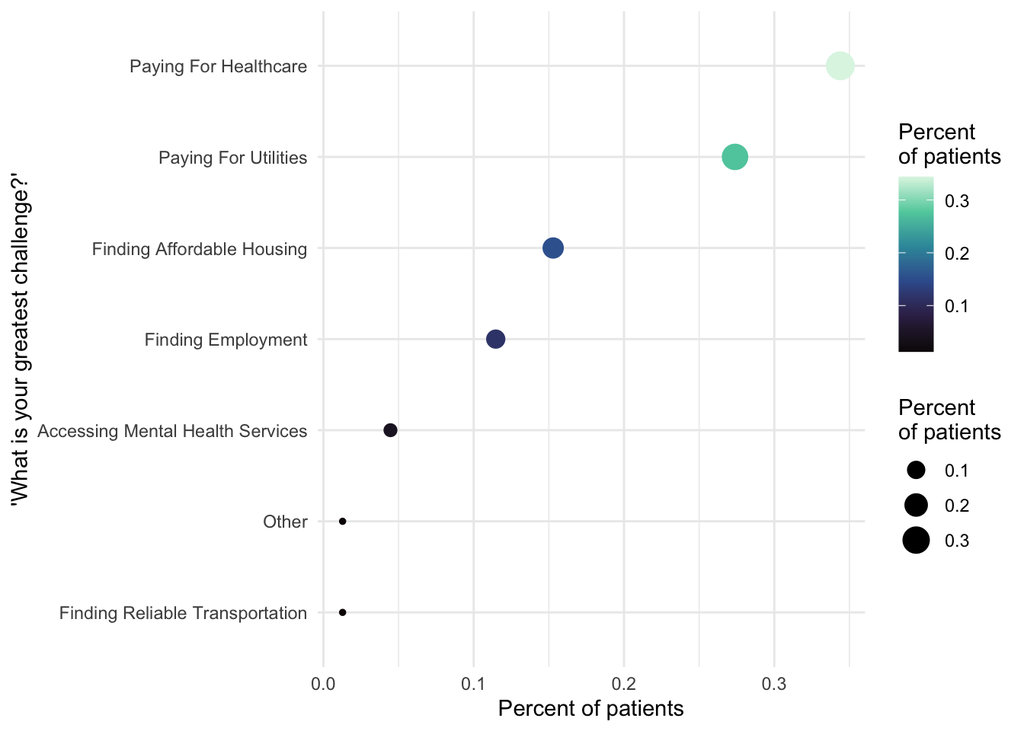

# *Summary:*

#### - **Demographics:** NHC sees twice as many females than males but an even split between Spanish and English patients. Their median age is 50 years old.

#### - **Financial Situation:** The median federal poverty level of NHC patients is 100%. Most (89%) NHC patients are uninsured. Less than half of NHC patients are working. Most NHC patients are not on financial assistance programs, but of those who are, SNAP is the most common.

#### - **Holistic Needs:** 30% of NHC patients are housing-insecure. 37% of NHC patients worry about food. 24% of NHC patients report having poor mental health. Besides access to healthcare, the greatest challenge NHC patients face is paying for utilites.

### *These results are likely impacted by NHC’s location and hours.*

#### Though very few patients reported having transportation difficulties, those who do have transportation hardships would not have been able to come to the clinic and take the survey. Moving the clinic to where the patients live or within walking distance of a bus stop could increase opportunities for the underserved population to be seen.

#### Since less than half of NHC patients work, this could be because NHC is only open during work hours. Changing the times NHC is open could also increase opportunities for the underserved to be seen. This is likely also why NHC sees twice as many women than men, since women are more likely to be stay-at-home wives and can be seen during clinic hours.

### *Action Items:*

#### - Begin/continue discussion of changing NHC location and hours.

#### - Add resources for programs that help pay for utilities in each exam room. (There is currently a box of resources in each room, but it does not have utility-related resources in it.)

##### *Let me know if you have any questions! -Haleigh*